# Tiny Project - COVID-19 Health Statistics Analysis

Tanmay Gupta

2026-09-05

## Introduction

This report analyzes the spread of COVID-19 across Indian states using daily reported data on confirmed cases, cured patients, and deaths. The dataset used is `covid_19_india.csv`, sourced from Kaggle.

## 1. Data Importing

```r
# Read the CSV file into R (must be in the same folder as this .Rmd file)
covid_data <- read.csv("covid_19_india.csv")

# Preview the first few rows
head(covid_data)
```

```
##   Sno       Date    Time State.UnionTerritory ConfirmedIndianNational
## 1   1 2020-01-30 6:00 PM               Kerala                       1
## 2   2 2020-01-31 6:00 PM               Kerala                       1
## 3   3 2020-02-01 6:00 PM               Kerala                       2
## 4   4 2020-02-02 6:00 PM               Kerala                       3
## 5   5 2020-02-03 6:00 PM               Kerala                       3
## 6   6 2020-02-04 6:00 PM               Kerala                       3
##   ConfirmedForeignNational Cured Deaths Confirmed
## 1                        0     0      0         1
## 2                        0     0      0         1
## 3                        0     0      0         2
## 4                        0     0      0         3
## 5                        0     0      0         3
## 6                        0     0      0         3
```

**Explanation:** `read.csv()` loads the dataset into a data frame called `covid_data`. `head()` shows the first 6 rows so we can confirm it loaded correctly.

## 2. Data Structure and Overview

```r
str(covid_data)
```

```
## 'data.frame':    18110 obs. of  9 variables:
##  $ Sno                     : int  1 2 3 4 5 6 7 8 9 10 ...
##  $ Date                    : chr  "2020-01-30" "2020-01-31" "2020-02-01" "2020-02-02" ...
##  $ Time                    : chr  "6:00 PM" "6:00 PM" "6:00 PM" "6:00 PM" ...
##  $ State.UnionTerritory    : chr  "Kerala" "Kerala" "Kerala" "Kerala" ...
##  $ ConfirmedIndianNational : chr  "1" "1" "2" "3" ...
##  $ ConfirmedForeignNational: chr  "0" "0" "0" "0" ...
##  $ Cured                   : int  0 0 0 0 0 0 0 0 0 0 ...
##  $ Deaths                  : int  0 0 0 0 0 0 0 0 0 0 ...
##  $ Confirmed               : int  1 1 2 3 3 3 3 3 3 3 ...
```

```r
summary(covid_data)
```

```
##       Sno               Date              Time       State.UnionTerritory
##  Min.   :    1   Length   :18110   Length   :18110   Length   :18110
##  1st Qu.: 4528   N.unique :  560   N.unique :    7   N.unique :   46
##  Median : 9056   N.blank  :    0   N.blank  :    0   N.blank  :    0
##  Mean   : 9056   Min.nchar:   10   Min.nchar:    7   Min.nchar:    3
##  3rd Qu.:13583   Max.nchar:   10   Max.nchar:    8   Max.nchar:   40
##  Max.   :18110
##  ConfirmedIndianNational ConfirmedForeignNational     Cured
##  Length   :18110         Length   :18110          Min.   :      0
##  N.unique :   62         N.unique :   12          1st Qu.:   3360
##  N.blank  :    0         N.blank  :    0          Median :  33364
##  Min.nchar:    1         Min.nchar:    1          Mean   : 278638
##  Max.nchar:    3         Max.nchar:    2          3rd Qu.: 278870
##                                                   Max.   :6159676
##      Deaths         Confirmed
##  Min.   :     0   Min.   :      0
##  1st Qu.:    32   1st Qu.:   4377
##  Median :   588   Median :  39774
##  Mean   :  4052   Mean   : 301031
##  3rd Qu.:  3644   3rd Qu.: 300150
##  Max.   :134201   Max.   :6363442
```

**Explanation:** `str()` shows the data type of each column (text, number, etc.). `summary()` gives quick statistics (min, max, average) for numeric columns like Confirmed, Cured, and Deaths.

## 3. Data Preprocessing and Cleaning

```r
# Check for missing values in each column
colSums(is.na(covid_data))
```

```
##                      Sno                     Date                     Time
##                        0                        0                        0
##     State.UnionTerritory  ConfirmedIndianNational ConfirmedForeignNational
##                        0                        0                        0
##                    Cured                   Deaths                Confirmed
##                        0                        0                        0
```

```r
# Convert Date column from text to proper Date format
covid_data$Date <- as.Date(covid_data$Date, format = "%Y-%m-%d")

# Confirm conversion worked
class(covid_data$Date)
```

```
## [1] "Date"
```

```r
# Check for duplicate rows
sum(duplicated(covid_data))
```

```
## [1] 0
```

**Explanation:** `colSums(is.na(...))` counts missing values per column. Converting `Date` to a proper date type lets R understand chronological order (needed for the trend chart later). We also check for duplicate rows to ensure data quality.

**Important note on this dataset:** each row stores a *cumulative running total* for a state as of that date (not new daily cases). This means we must NOT simply add up every row later — that would multiply the same growing numbers across ~500 days and give impossible totals. Instead, for any “grand total,” we will use only the **most recent date’s** rows, since those already represent the final cumulative count for each state.

## 4. Data Analysis and Statistical Exploration

```r
# Isolate only the most recent date's data (correct final totals per state)
latest_date <- max(covid_data$Date)
latest_data <- covid_data[covid_data$Date == latest_date, ]

latest_date
```

```
## [1] "2021-08-11"
```

```r
# Overall totals across India (as of the latest date)
total_confirmed <- sum(latest_data$Confirmed)
total_cured <- sum(latest_data$Cured)
total_deaths <- sum(latest_data$Deaths)

total_confirmed
```

```
## [1] 32036511
```

```r
total_cured
```

```
## [1] 31220981
```

```r
total_deaths
```

```
## [1] 429179
```

```r
# Which states have the highest confirmed cases (as of latest date)?
state_totals <- latest_data[order(-latest_data$Confirmed),
                             c("State.UnionTerritory", "Confirmed")]
head(state_totals, 10)
```

```
##       State.UnionTerritory Confirmed
## 18095          Maharashtra   6363442
## 18091               Kerala   3586693
## 18090            Karnataka   2921049
## 18105           Tamil Nadu   2579130
## 18076       Andhra Pradesh   1985182
## 18109        Uttar Pradesh   1708812
## 18110          West Bengal   1534999
## 18083                Delhi   1436852
## 18081         Chhattisgarh   1003356
## 18100               Odisha    988997
```

```r
# Central tendency and spread of confirmed cases across states (latest date)
median(latest_data$Confirmed)
```

```
## [1] 461794.5
```

```r
var(latest_data$Confirmed)
```

```
## [1] 1.663263e+12
```

```r
sd(latest_data$Confirmed)
```

```
## [1] 1289676
```

```r
# Frequency count: number of days each state has reported data
state_freq <- table(covid_data$State.UnionTerritory)
head(state_freq)
```

```
##
## Andaman and Nicobar Islands              Andhra Pradesh
##                         504                         518
##           Arunachal Pradesh                       Assam
##                         496                         498
##                       Bihar                   Bihar****
##                         506                           2
```

```r
# Correlation between Confirmed cases and Deaths (using full daily data)
cor(covid_data$Confirmed, covid_data$Deaths)
```

```
## [1] 0.9183455
```

```r
# Correlation between Confirmed cases and Cured (using full daily data)
cor(covid_data$Confirmed, covid_data$Cured)
```

```
## [1] 0.9977507
```

**Explanation:** We use `latest_data` (a single date’s snapshot) for grand totals and state rankings, since the data is cumulative. `median()`, `var()`, and `sd()` show how spread out the case counts are across states — a large standard deviation means some states had far more cases than others. `table()` counts how many days of data exist per state, useful for checking data completeness. For correlation, using the full daily dataset is fine and standard practice, because correlation measures the *relationship* between two columns’ growth pattern, not an absolute total.

## 5. Graphs and Plots

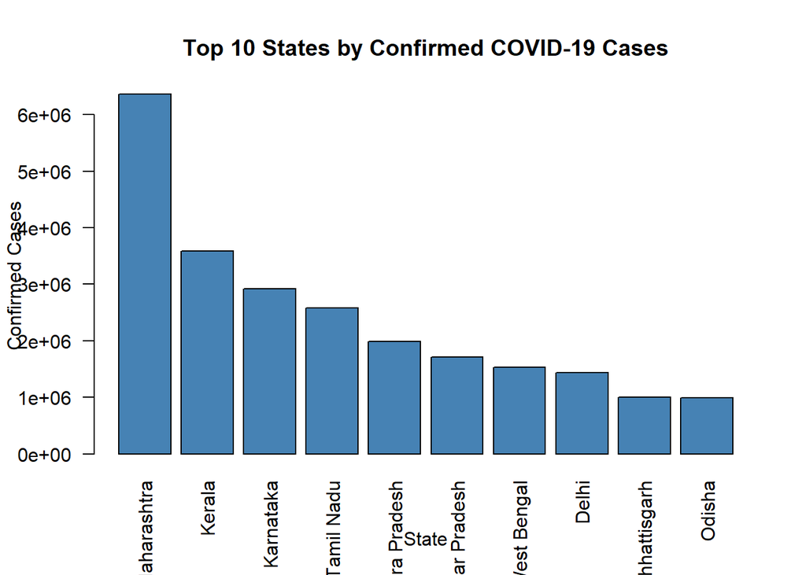

```r
# Bar chart: Top 10 states by confirmed cases
top10 <- head(state_totals, 10)

barplot(
  top10$Confirmed,
  names.arg = top10$State.UnionTerritory,
  main = "Top 10 States by Confirmed COVID-19 Cases",
  xlab = "State",
  ylab = "Confirmed Cases",
  las = 2,
  col = "steelblue"
)
```

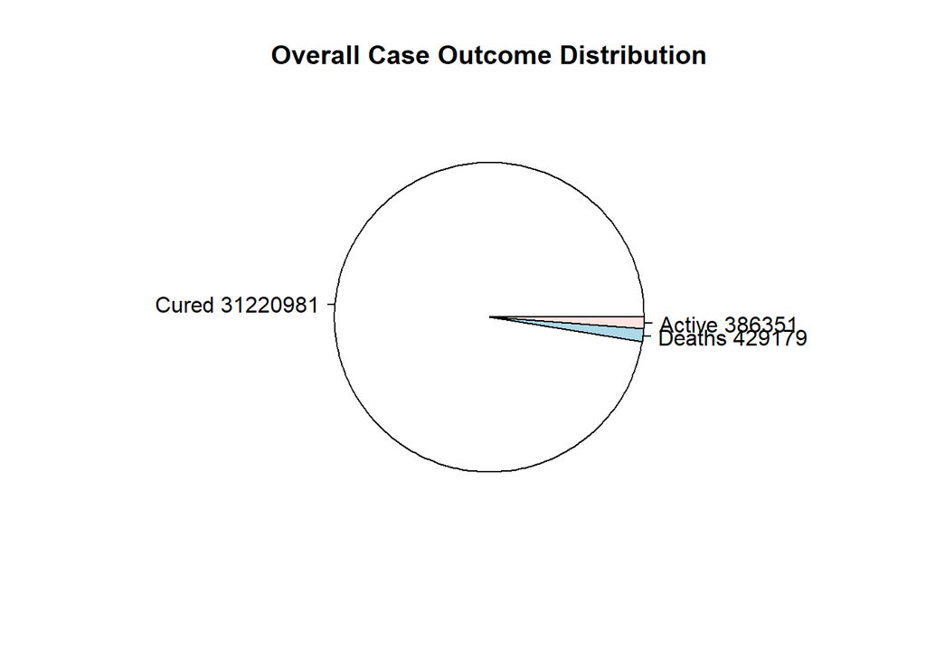

```r
# Pie chart: overall outcome split (Cured vs Deaths vs Active)
active <- total_confirmed - total_cured - total_deaths

outcome <- c(Cured = total_cured, Deaths = total_deaths, Active = active)

pie(
  outcome,
  main = "Overall Case Outcome Distribution",
  labels = paste(names(outcome), outcome)
)
```

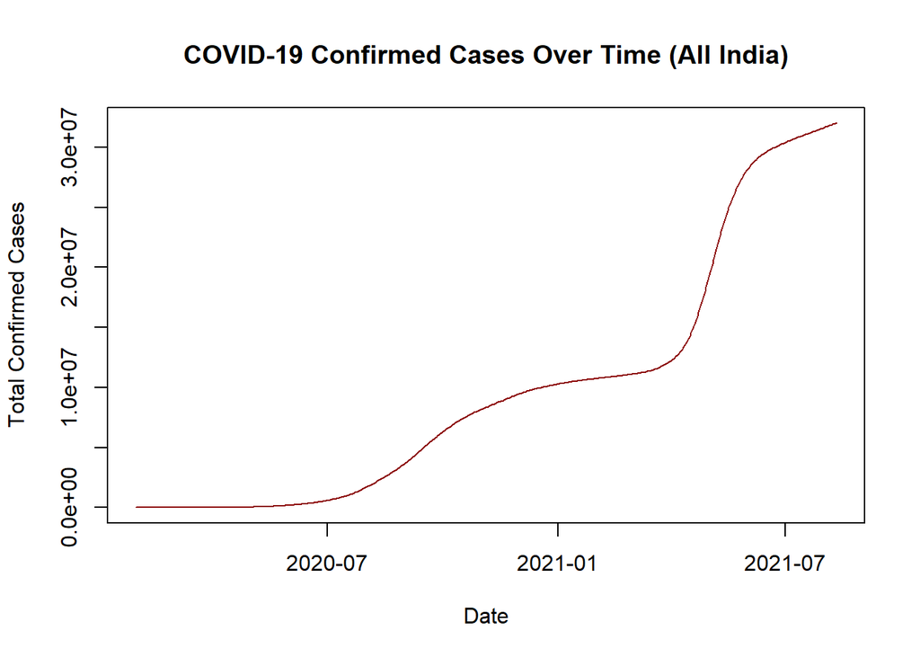

```r
# Line trend: total confirmed cases over time (all states combined)
daily_totals <- aggregate(Confirmed ~ Date, data = covid_data, sum)

plot(
  daily_totals$Date,
  daily_totals$Confirmed,
  type = "l",
  main = "COVID-19 Confirmed Cases Over Time (All India)",
  xlab = "Date",
  ylab = "Total Confirmed Cases",
  col = "darkred"
)
```

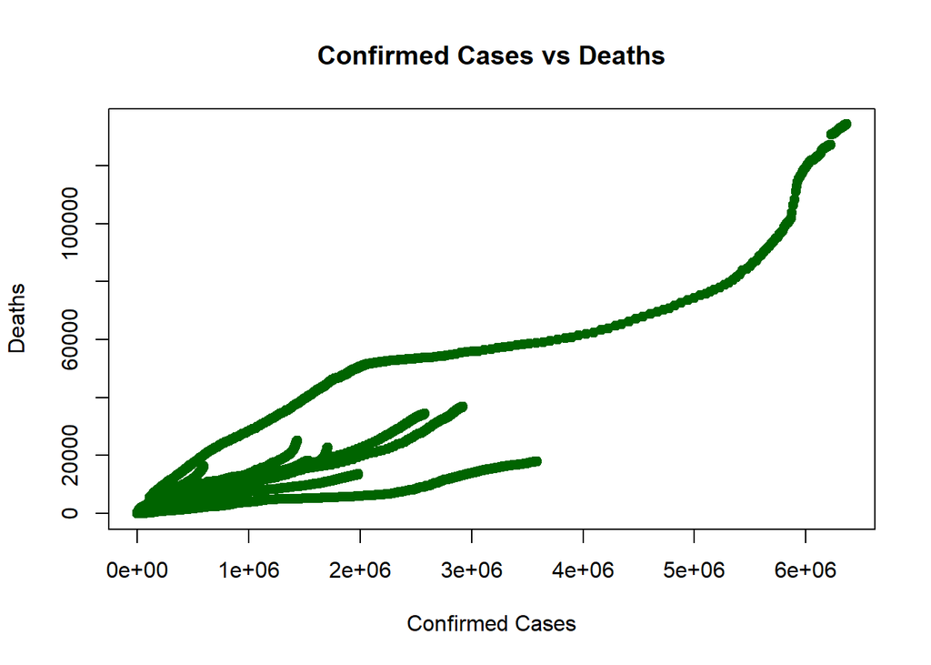

```r
# Scatter plot: Confirmed vs Deaths relationship
plot(
  covid_data$Confirmed,
  covid_data$Deaths,
  main = "Confirmed Cases vs Deaths",
  xlab = "Confirmed Cases",
  ylab = "Deaths",
  pch = 19,
  col = "darkgreen"
)
```

**Explanation:** The bar chart highlights the worst-affected states as of the most recent date. The pie chart shows the overall proportion of patients cured, deceased, or still active. The line plot shows how the national case count grew over time. The scatter plot visualizes the relationship between case count and deaths across all states and dates.

## 6. Findings and Conclusion

- The state of **Maharashtra** recorded the highest number of confirmed cases (6,363,442), suggesting it was the most affected region in the country, followed by Kerala and Karnataka.
- The correlation between Confirmed cases and Deaths was **0.918**, indicating a **strong** positive relationship — meaning states with more cases generally also recorded proportionally more deaths.
- The correlation between Confirmed cases and Cured was **0.998**, an even **stronger** relationship, showing recoveries closely tracked the rise in confirmed cases over time.
- The trend line shows cases **rose sharply** in two distinct phases — a steep climb during mid-to-late 2020, followed by an even sharper spike in **April-May 2021**, reflecting India’s second COVID-19 wave.
- Overall, out of all confirmed cases (32,036,511 total), **97.45%** were cured, and **1.34%** resulted in death, showing a **high** recovery rate.

**Conclusion:** This analysis of India’s COVID-19 data shows how the pandemic spread unevenly across states, with Maharashtra, Kerala, and Karnataka bearing a disproportionate share of cases. The strong correlation between cases and deaths/recoveries highlights the scale of the healthcare response required during the outbreak, while the high overall recovery rate of over 97% reflects the effectiveness of treatment and containment efforts over time.